# Final Project Tutorial: U.S. Pollution Data

Shawn Jassal

5/22/2019

# Introduction

In this tutorial we will take you throught the Data Science Pipleline.  
1. Gather Data  
2. Tidy and Clean the Data  
3. Visualize the Data  
4. Model the Data  
5. Interpret the Results  
We will apply this to pollution in the United States. We will use the NO2 Air Quality Index (AQI), O3 AQI, SO2 AQI, and CO AQI. Then we will tidy and clean the data, to remove unnecessary data. Next, we will visualize the data with various plots and maps. We will use what we learned and develop a hypothesis. Then we will test the hypothesis using machine learning.

# Libraries Required

- [tidyverse](https://www.rdocumentation.org/packages/tidyverse/versions/1.2.1)
- [dplyr](https://www.rdocumentation.org/packages/dplyr/versions/0.5.0)
- [ggplot2](https://www.rdocumentation.org/packages/ggplot2/versions/3.1.1)
- [leaflet](https://www.rdocumentation.org/packages/leaflet/versions/2.0.2)
- [shiny](https://shiny.rstudio.com/)
- [geojsonio](https://www.rdocumentation.org/packages/geojsonio/versions/0.7.0)
- [caret](https://www.rdocumentation.org/packages/caret/versions/6.0-84)
- [broom](https://www.rdocumentation.org/packages/broom/versions/0.5.2)

Tidyverse and dplyr are just to make our lives easier. ggplot2 will help us create plots. Leaflet and Shiny will allows us to create interactive maps, that will help veiw our data. Lastly, geojsonio will help us better view the maps we create using leaflet and shiny. Caret, broom, and plotROC will help with creating and analyzing our model.

# 1. Getting Started

## 1.1 Get the Data

We will get our data from [Kaggle](https://www.kaggle.com/sogun3/uspollution). You might need a Kaggle account, but it is worth getting due to all of the datasets available. All we need to do is download the .csv file and read it. This data gives us data collected about the pollutants, NO2, O3, SO2, and CO. All of these are within the U.S between 2000 - 2016. However, data is not for every state, and is not consistent. So sometimes we will have missing data for one year in a certain state. It is worth noting that this data set has nearly about 1.7 million entries, so some operation will be slow.

```r
# Data from: https://www.kaggle.com/sogun3/uspollution/downloads/uspollution.zip/1
csv_file <- "pollution_us_2000_2016.csv"
tidy_df <- read_csv(csv_file)
tidy_df
```

```
## # A tibble: 1,746,661 x 29
##       X1 `State Code` `County Code` `Site Num` Address State County City
##    <dbl>        <dbl>         <dbl>      <dbl> <chr>   <chr> <chr>  <chr>
##  1     0            4            13       3002 1645 E~ Ariz~ Maric~ Phoe~
##  2     1            4            13       3002 1645 E~ Ariz~ Maric~ Phoe~
##  3     2            4            13       3002 1645 E~ Ariz~ Maric~ Phoe~
##  4     3            4            13       3002 1645 E~ Ariz~ Maric~ Phoe~
##  5     4            4            13       3002 1645 E~ Ariz~ Maric~ Phoe~
##  6     5            4            13       3002 1645 E~ Ariz~ Maric~ Phoe~
##  7     6            4            13       3002 1645 E~ Ariz~ Maric~ Phoe~
##  8     7            4            13       3002 1645 E~ Ariz~ Maric~ Phoe~
##  9     8            4            13       3002 1645 E~ Ariz~ Maric~ Phoe~
## 10     9            4            13       3002 1645 E~ Ariz~ Maric~ Phoe~
## # ... with 1,746,651 more rows, and 21 more variables: `Date
## #   Local` <date>, `NO2 Units` <chr>, `NO2 Mean` <dbl>, `NO2 1st Max
## #   Value` <dbl>, `NO2 1st Max Hour` <dbl>, `NO2 AQI` <dbl>, `O3
## #   Units` <chr>, `O3 Mean` <dbl>, `O3 1st Max Value` <dbl>, `O3 1st Max
## #   Hour` <dbl>, `O3 AQI` <dbl>, `SO2 Units` <chr>, `SO2 Mean` <dbl>, `SO2
## #   1st Max Value` <dbl>, `SO2 1st Max Hour` <dbl>, `SO2 AQI` <dbl>, `CO
## #   Units` <chr>, `CO Mean` <dbl>, `CO 1st Max Value` <dbl>, `CO 1st Max
## #   Hour` <dbl>, `CO AQI` <dbl>
```

## 1.2 Tidy and Clean the Data

```r
# Remove the columns: row number ("X1"), State Code, Country Code, Site Num, Address, and County
tidy_df <- tidy_df[-c(1:5,7)]

# Now delete all of the Units columns
# NO2 = parts per billion; O3  = parts per million; SO2 = parts per billion; CO  = parts per million
tidy_df <- tidy_df[-c(5,10,15,20)]

# Remove the hour of the max value columns
tidy_df <- tidy_df[-c(4,8,12,16)]

# rename date column a DATE variable
colnames(tidy_df)[3] <- "Date"
tidy_df <- type_convert(tidy_df, col_types = cols("Date" = col_datetime("%Y-%m-%d")))

# Add a year column to speed up data visualization
tidy_df$year <- substring(tidy_df$Date,1,4)

# Add a month column
tidy_df$month <- substring(tidy_df$Date,6,7)
tidy_df
```

```
## # A tibble: 1,746,661 x 17
##    State City  Date       `NO2 1st Max Va~ `NO2 1st Max Ho~ `NO2 AQI`
##    <chr> <chr> <date>                <dbl>            <dbl>     <dbl>
##  1 Ariz~ Phoe~ 2000-01-01               49               19        46
##  2 Ariz~ Phoe~ 2000-01-01               49               19        46
##  3 Ariz~ Phoe~ 2000-01-01               49               19        46
##  4 Ariz~ Phoe~ 2000-01-01               49               19        46
##  5 Ariz~ Phoe~ 2000-01-02               36               19        34
##  6 Ariz~ Phoe~ 2000-01-02               36               19        34
##  7 Ariz~ Phoe~ 2000-01-02               36               19        34
##  8 Ariz~ Phoe~ 2000-01-02               36               19        34
##  9 Ariz~ Phoe~ 2000-01-03               51                8        48
## 10 Ariz~ Phoe~ 2000-01-03               51                8        48
## # ... with 1,746,651 more rows, and 11 more variables: `O3 1st Max
## #   Value` <dbl>, `O3 1st Max Hour` <dbl>, `O3 AQI` <dbl>, `SO2 1st Max
## #   Value` <dbl>, `SO2 1st Max Hour` <dbl>, `SO2 AQI` <dbl>, `CO 1st Max
## #   Value` <dbl>, `CO 1st Max Hour` <dbl>, `CO AQI` <dbl>, year <chr>,
## #   month <chr>
```

Since we plan on putting our data on an interactive we will need the longitude and lattitude of each of the cities. We wil get a list of big cities and their longitude and lattitude from [here](https://simplemaps.com/data/us-cities). We will collect this data and remove any of the unneccesary columns. Then we will use left_join to add the values we need to create our interactive. We use a left join because we want to keep as much data as possible, and we don’t want to keep cities that we don’t have data for.

```r
# Data from: https://simplemaps.com/data/us-cities
# Now get longitude and latitude of each locaiton
csv_file <- "uscitiesv1.5.csv"
cities_df <- read_csv(csv_file)
# Remove useless columns
cities_df <- cities_df[-c(2,3,5,6,9:16)]
colnames(cities_df)[1] <- "City"
colnames(cities_df)[2] <- "State"

# Join the two table on City and State to get Longitude and latitude
tidy_df <- left_join(tidy_df, cities_df, by= c("City", "State"))
tidy_df
```

```
## # A tibble: 1,746,661 x 19
##    State City  Date       `NO2 1st Max Va~ `NO2 1st Max Ho~ `NO2 AQI`
##    <chr> <chr> <date>                <dbl>            <dbl>     <dbl>
##  1 Ariz~ Phoe~ 2000-01-01               49               19        46
##  2 Ariz~ Phoe~ 2000-01-01               49               19        46
##  3 Ariz~ Phoe~ 2000-01-01               49               19        46
##  4 Ariz~ Phoe~ 2000-01-01               49               19        46
##  5 Ariz~ Phoe~ 2000-01-02               36               19        34
##  6 Ariz~ Phoe~ 2000-01-02               36               19        34
##  7 Ariz~ Phoe~ 2000-01-02               36               19        34
##  8 Ariz~ Phoe~ 2000-01-02               36               19        34
##  9 Ariz~ Phoe~ 2000-01-03               51                8        48
## 10 Ariz~ Phoe~ 2000-01-03               51                8        48
## # ... with 1,746,651 more rows, and 13 more variables: `O3 1st Max
## #   Value` <dbl>, `O3 1st Max Hour` <dbl>, `O3 AQI` <dbl>, `SO2 1st Max
## #   Value` <dbl>, `SO2 1st Max Hour` <dbl>, `SO2 AQI` <dbl>, `CO 1st Max
## #   Value` <dbl>, `CO 1st Max Hour` <dbl>, `CO AQI` <dbl>, year <chr>,
## #   month <chr>, lat <dbl>, lng <dbl>
```

# 2. Exploratory Data Analysis

Now that we have clean our data, we can analyze it. This will allow us to better view trends and patterns within the data. First we wil visualize the data then look at the statistics of the data.

## 2.1 Interactive Maps

These maps will help us see general trends of NO2 AQI over time. However, due to the limitations of getting shinyapp.io to work, and time restrictions, you will have to build this yourself.  
If you want to build this for your self, **[download this .rmd file](https://github.com/ShawnJ99/ShawnJ99.github.io/blob/master/build-Maps.Rmd)**. Then you need to download the data files:  
* [Pollution Data](https://www.kaggle.com/sogun3/uspollution/downloads/uspollution.zip/1)  
* [Longitude and Latitude Data](https://simplemaps.com/data/us-cities)  
* [Map Outline](https://github.com/PublicaMundi/MappingAPI/blob/master/data/geojson/us-states.json)  
+ Note: you may need to change .json to .geojson  
Now you just need to build it in RStudio. In the .rmd file there are maps for NO2, O3, SO2, and CO, so you can make your own observations and analysis. Despite this, we can still view some pictures of the data for NO2.  
Before we can analyze the data we must first understand what AQI means. From [here](https://airnow.gov/index.cfm?action=aqibasics.aqi) we can learn the basics of Air Quality Index (AQI). * 0 - 50 = Good * 51 - 100 = Moderate * 101 - 150 = Unhealthy for Sensitive groups * 151 - 200 = Unhealthy * 201 - 300 = Very Unhealthy * 301 - 500 = Hazardous This will help us understand how each state is doing, what are there pollution levels. An interesting thing to note is that the EPA has set the air quality standard to a value of 100.

During the preprocessing step we will create an Icon to see where the data collecting sites are located. We will also create a seperate data frame with data we need to place these Icons. We will also use a .geojson file which will help us add markers, and view the exact AQI of each state when using the interactive map. Lastly, we will divide the data into bins to group the AQI levels. When creating our palette we will set any states that don’t have any data to black.

```r
# Create Icon
# Map Marker From: http://simpleicon.com/map-marker-2.html
myIcon <- makeIcon(
  iconUrl = "http://www.myiconfinder.com/uploads/iconsets/256-256-a5485b563efc4511e0cd8bd04ad0fe9e.png",
  iconWidth = 8, iconHeight = 9,
  iconAnchorX = 5, iconAnchorY = 5
)

# Create data frame with markers of all locations
markers_df <- tidy_df %>%
  distinct(City) %>%
  inner_join(select(tidy_df, City, lng, lat), by = "City") %>%
  distinct()

# Get From Here: https://github.com/PublicaMundi/MappingAPI/blob/master/data/geojson/us-states.json
# GitHub thread about the file: https://github.com/rstudio/leaflet/issues/498
states <- geojsonio::geojson_read("us-states.geojson", what = "sp")
# Create data frame with State names
states_name <- select(as.data.frame(states), name)
colnames(states_name)[1] <- "State"

# Create colors and palletes
bins <- c(0, 5, 10, 15, 20, 25, 30, 35, 40, Inf)
pal <- colorBin(palette="YlOrRd", domain = states$density, na.color = "000", bins = bins)
```

Now in our map, we will set the map to the year 2000, and get the data for that year. In our ui we create a panel for the slider, and make it so that you can animate it to view the data over time, without having to click through it. Then we will create the maps with outlines of each state. Next, we observe the slider, and change the data shown depending on the year of the slider.

```r
# Set to NO2 AQI at the year 2000
temp_df <- tidy_df %>%
  filter(year == 2000) %>%
  select(State, `NO2 AQI`) %>%
  group_by(State) %>%
  summarise(x = mean(`NO2 AQI`, na.rm = TRUE)) %>%
  right_join(states_name, by = "State")

colnames(temp_df)[2] <- "density"
# Set new density values
states$density <- temp_df$density

labels <- sprintf(
  "<strong>%s</strong><br/>%g AQI",
  states$name, states$density
) %>% lapply(htmltools::HTML)

ui <- fluidPage(
  leafletOutput("map"),
  sidebarLayout(
    sidebarPanel(
      sliderInput("Year", "Year:", min = 2000, max = 2016, value = 2000,
                  animate = animationOptions(interval = 2000, loop = FALSE))
    ),
    mainPanel(
      tableOutput("Year")
    )
  )
)

server <- function(input, output, session){
  sliderValues <- reactive({
    data.frame(
      Name = c("Year"),
      Value = as.character(c(input$Year), stringsAsFactors = FALSE))
  })
  output$map <- renderLeaflet({
    map <- leaflet(states) %>%
      addProviderTiles("MapBox", options = providerTileOptions(
        id = "mapbox.light",
        accessToken = Sys.getenv('MAPBOX_ACCESS_TOKEN'))) %>%
      addPolygons(
        fillColor = ~pal(states$density),
        weight = 2,
        opacity = 1,
        color = "white",
        dashArray = "3",
        fillOpacity = 0.7,
        highlight = highlightOptions(
          weight = 5,
          color = "#666",
          dashArray = "",
          fillOpacity = 0.7,
          bringToFront = TRUE),
        label = labels,
        labelOptions = labelOptions(
          style = list("font-weight" = "normal", padding = "3px 8px"),
          textsize = "15px",
          direction = "auto")) %>%
      addLegend(pal = pal, values = ~density, opacity = 0.7, title = NULL,
                position = "bottomright") %>%
      addMarkers(markers_df$lng, markers_df$lat, popup = markers_df$City, icon = myIcon) %>%
      setView(lat=39.508577, lng=-98.322468, zoom=4)
  })

  observe({
    # Set zoom and center map
    zoom <- reactive({
      ifelse(is.null(input$map01_zoom),4,input$map01_zoom)
    })
    center <- reactive({
        if(is.null(input$map01_center)){
          return(c(39.508577, -98.322468))
          }else{
            return(input$map01_center)
          }
    })

    # Get new data based off of year value
    temp_df <- tidy_df %>%
      filter(year == input$Year) %>%
      select(State, `NO2 AQI`) %>%
      group_by(State) %>%
      summarise(x = mean(`NO2 AQI`,na.rm = TRUE)) %>%
      right_join(states_name, by = "State")
    colnames(temp_df)[2] <- "density"
    # Set new density values
    states$density <- temp_df$density

    # Update the map
    output$map <- renderLeaflet({
      map <- leaflet(states) %>%
        addProviderTiles("MapBox", options = providerTileOptions(
          id = "mapbox.light",
          accessToken = Sys.getenv('MAPBOX_ACCESS_TOKEN'))) %>%
        addPolygons(
          fillColor = ~pal(states$density),
          weight = 2,
          opacity = 1,
          color = "white",
          dashArray = "3",
          fillOpacity = 0.7,
          highlight = highlightOptions(
            weight = 5,
            color = "#666",
            dashArray = "",
            fillOpacity = 0.7,
            bringToFront = TRUE),
          label = labels,
          labelOptions = labelOptions(
            style = list("font-weight" = "normal", padding = "3px 8px"),
            textsize = "15px",
            direction = "auto")) %>%
        addLegend(pal = pal, values = ~density, opacity = 0.7, title = NULL,
                  position = "bottomright") %>%
        addMarkers(markers_df$lng, markers_df$lat, popup = markers_df$City, icon = myIcon) %>%
        setView(lat=center()[1], lng=center()[2], zoom=zoom())
    })
  })
}
# Run shiny
shinyApp(ui, server)
```

Now that we have proccessed our data we can start to analyze it for trends. The first thing you will notice is that a lot of states are blacked-out, this is because not all states had data, and some didn’t have consistent data, and we did not have enough information to predict the data. From looking at the images you can see that both California and Texas, had a high AQI index and it went down over time. Also, you can see that between 2000-2010 New York was improving, but in 2016 there AQI went back up. We can see that it appears that the general trend is that NO2 AQI was decreasing.

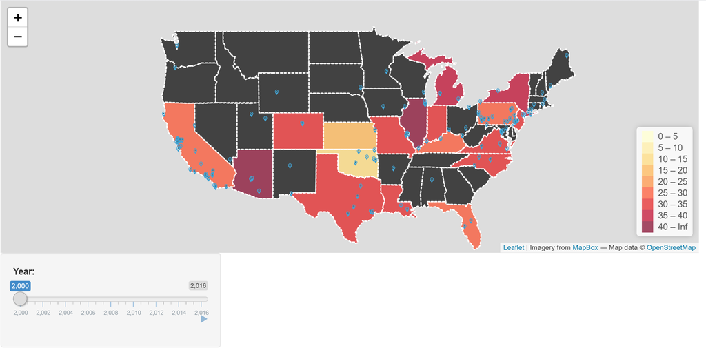

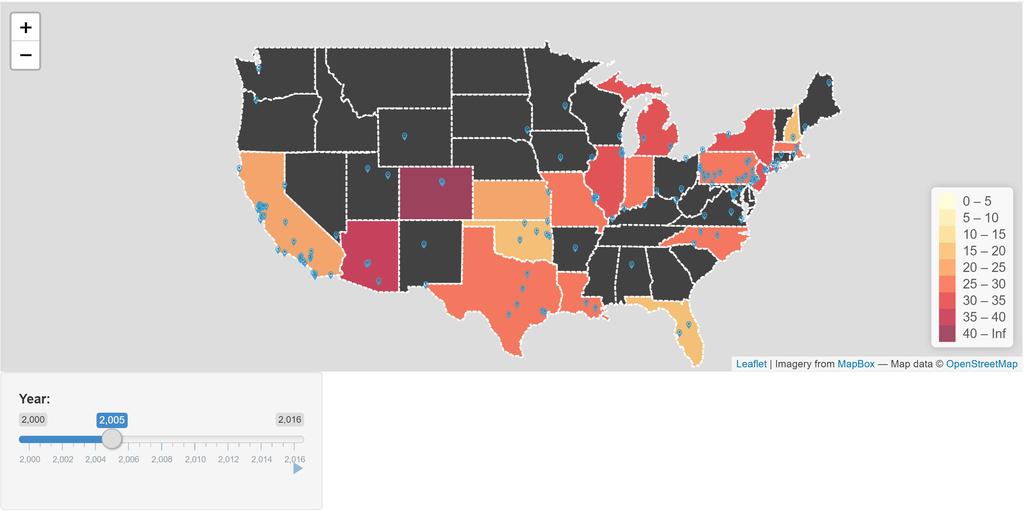

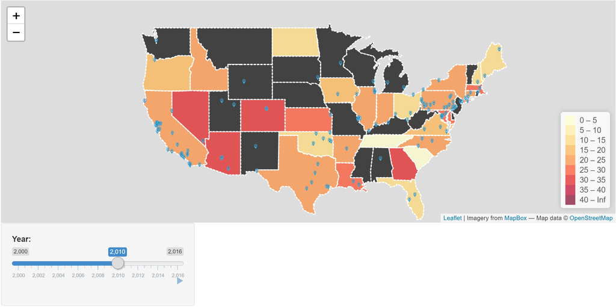

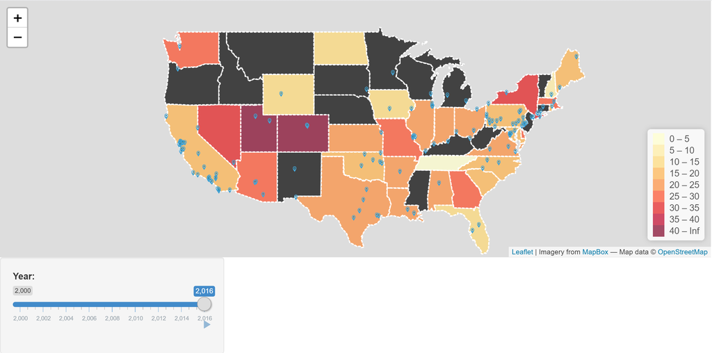

## 2.2 Air Quality Line Plots

Here we can see line plots of the median and mean, of each pollutant. For NO2 we can see that it has been decreasing over time. Which is really good since before it was getting close to being in the range of “Mderate” AQI. However, in 2016 we did see an increase in data. However, we can say that this is not too important, because the data collected in 2016 is only for the first few months.

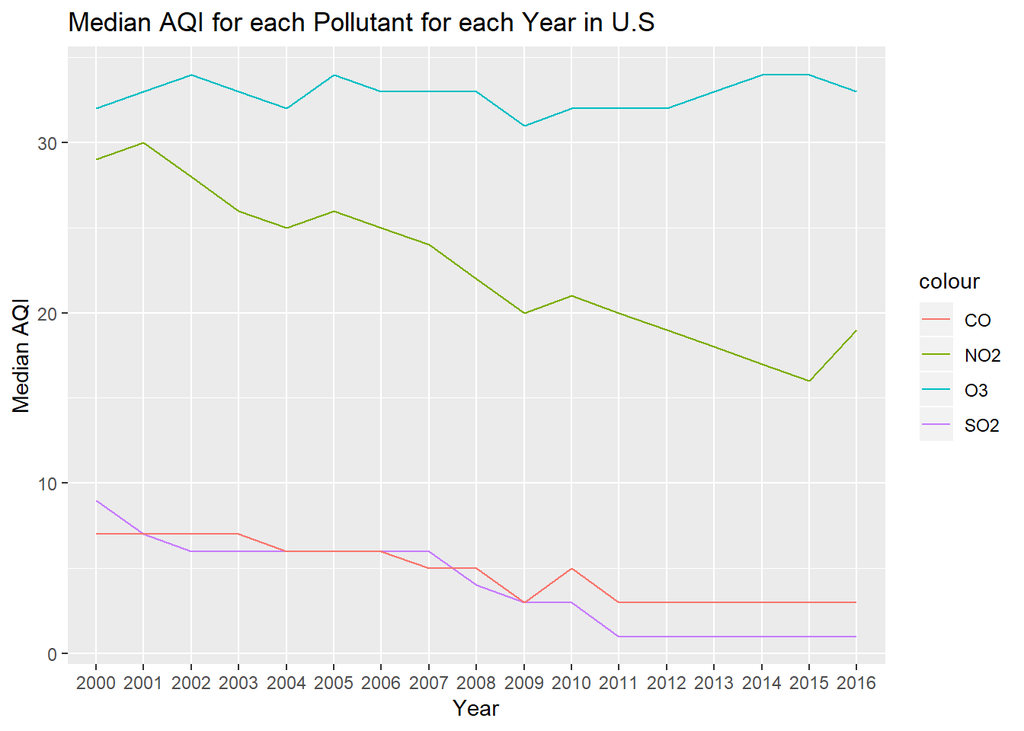

```r
tidy_df %>%
  group_by(year) %>%
  summarise(median_NO2_AQI = median(`NO2 AQI`, na.rm = TRUE),
            median_O3_AQI = median(`O3 AQI`, na.rm = TRUE),
            median_SO2_AQI = median(`SO2 AQI`, na.rm = TRUE),
            median_CO_AQI = median(`CO AQI`, na.rm = TRUE)) %>%
  ggplot() +
  geom_line(aes(x=year, y=median_NO2_AQI, group = 1, color = "NO2")) +
  geom_line(aes(x=year, y=median_O3_AQI, group = 2, color = "O3")) +
  geom_line(aes(x=year, y=median_SO2_AQI, group = 3, color = "SO2")) +
  geom_line(aes(x=year, y=median_CO_AQI, group = 4, color = "CO")) +
  labs(title = "Median AQI for each Pollutant for each Year in U.S", x = "Year", y = "Median AQI")
```

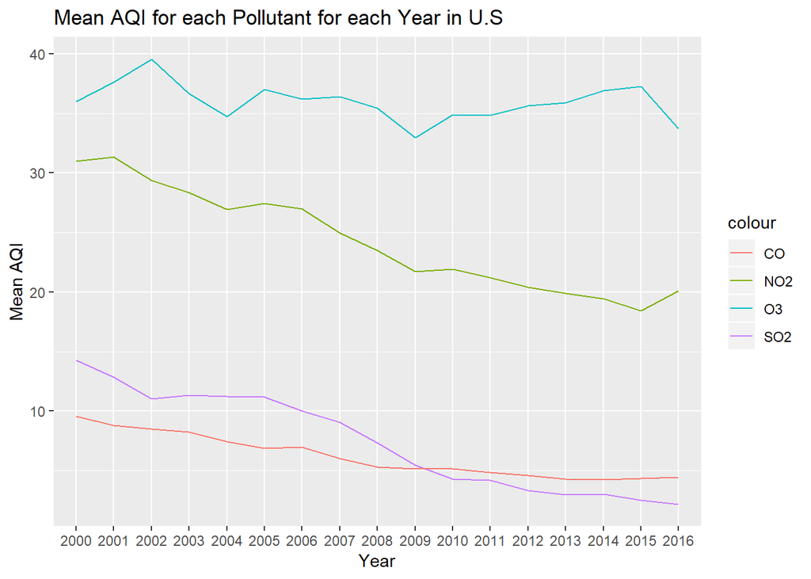

```r
tidy_df %>%
  group_by(year) %>%
  summarise(mean_NO2_AQI = mean(`NO2 AQI`, na.rm = TRUE),
            mean_O3_AQI = mean(`O3 AQI`, na.rm = TRUE),
            mean_SO2_AQI = mean(`SO2 AQI`, na.rm = TRUE),
            mean_CO_AQI = mean(`CO AQI`, na.rm = TRUE)) %>%
  ggplot() +
  geom_line(aes(x=year, y=mean_NO2_AQI, group = 1, color = "NO2")) +
  geom_line(aes(x=year, y=mean_O3_AQI, group = 2, color = "O3")) +
  geom_line(aes(x=year, y=mean_SO2_AQI, group = 3, color = "SO2")) +
  geom_line(aes(x=year, y=mean_CO_AQI, group = 4, color = "CO")) +
  labs(title = "Mean AQI for each Pollutant for each Year in U.S", x = "Year", y = "Mean AQI")
```

## 2.3 Air Quality Index Box Plots

Now lets look look at box plots of the data so that we can see the spread of the data. We have seen that our observations from the maps were correct about the decrease in AQI in the U.S. We can see that the median NO2 AQI in the U.S is has been decreasing over the years. We can also recall that means that we are staying in the “Good” range of AQI. O3, SO2 and CO have very small spreads, which means that the levels be very different for each state. In all of the boxplots we can see that there are a lot of outliers, so again this supports this agrees with what we saw in the interactive maps, that pollution is very dependent on state. It is also worth noting that SO2 and CO come up with warnings, this is because not all locations collected data on these pollutants, so they have significantly less data than the NO2 and O3.

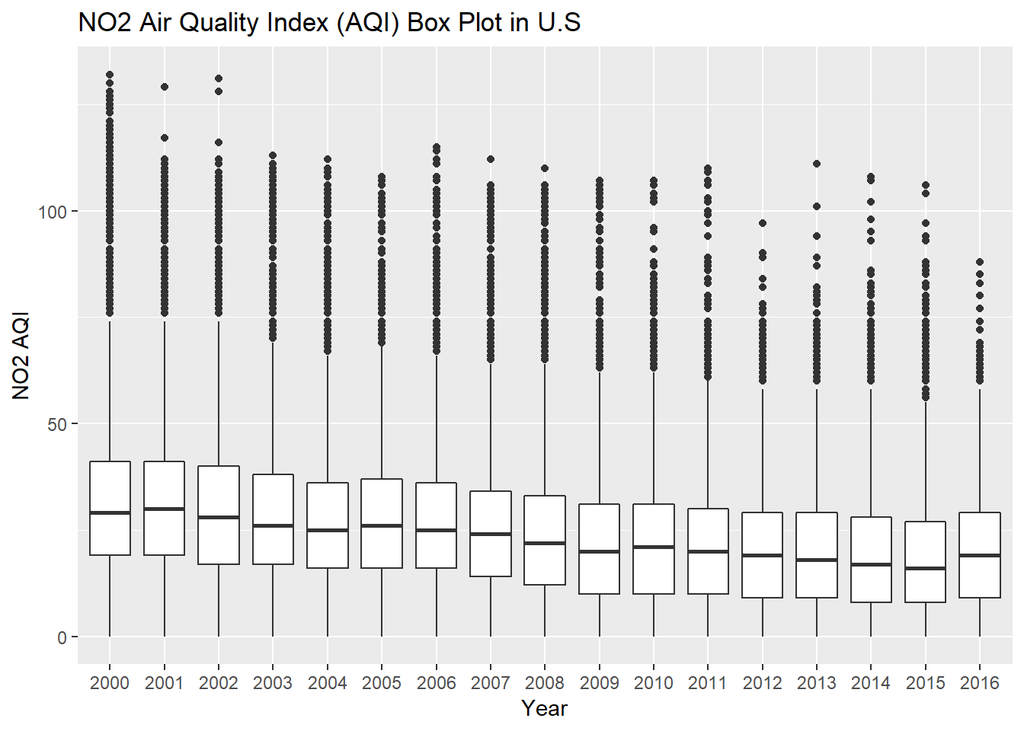

```r
tidy_df %>%
  ggplot(aes(x=year, y=`NO2 AQI`)) +
  geom_boxplot() +
  labs(title = "NO2 Air Quality Index (AQI) Box Plot in U.S", x = "Year", y = "NO2 AQI")
```

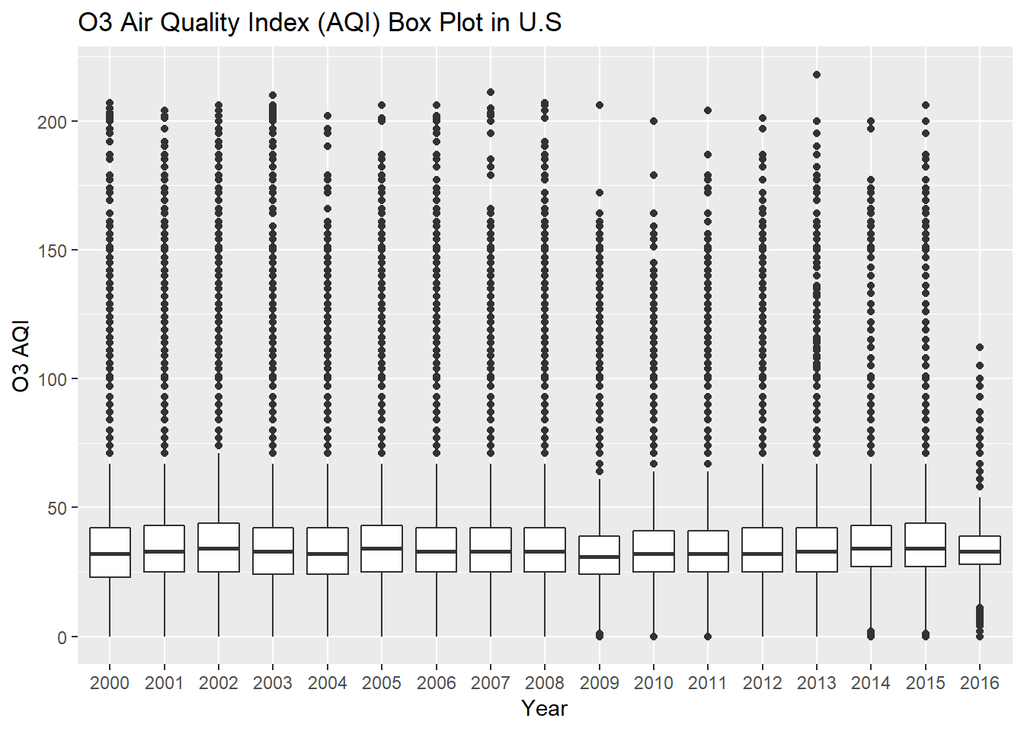

```r
tidy_df %>%
  ggplot(aes(x=year, y=`O3 AQI`)) +
  geom_boxplot() +
  labs(title = "O3 Air Quality Index (AQI) Box Plot in U.S", x = "Year", y = "O3 AQI")
```

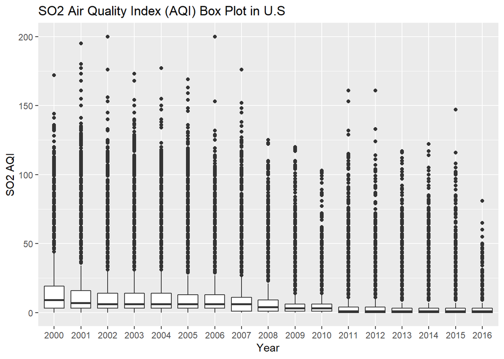

```r
tidy_df %>%
  ggplot(aes(x=year, y=`SO2 AQI`)) +
  geom_boxplot() +
  labs(title = "SO2 Air Quality Index (AQI) Box Plot in U.S", x = "Year", y = "SO2 AQI")
```

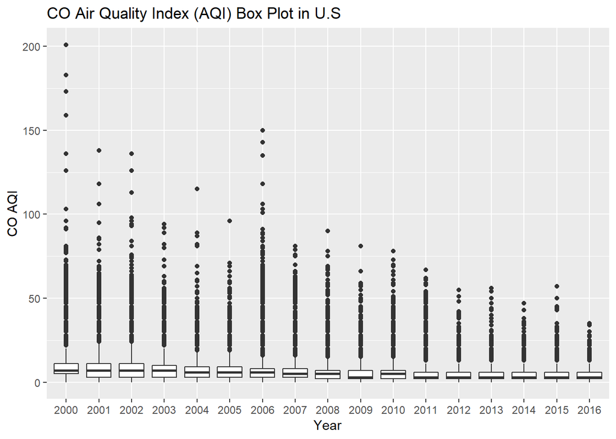

```r
tidy_df %>%
  ggplot(aes(x=year, y=`CO AQI`)) +
  geom_boxplot() +
  labs(title = "CO Air Quality Index (AQI) Box Plot in U.S", x = "Year", y = "CO AQI")
```

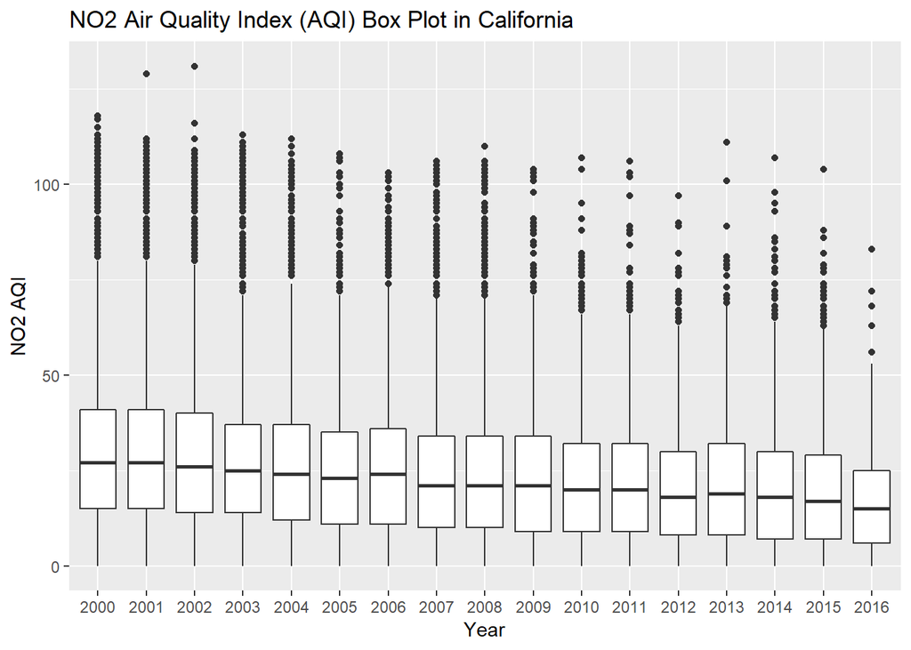

```r
tidy_df %>%
  filter(State == "California") %>%
  ggplot(aes(x=year, y=`NO2 AQI`)) +
  geom_boxplot() +
  labs(title = "NO2 Air Quality Index (AQI) Box Plot in California", x = "Year", y = "NO2 AQI")
```

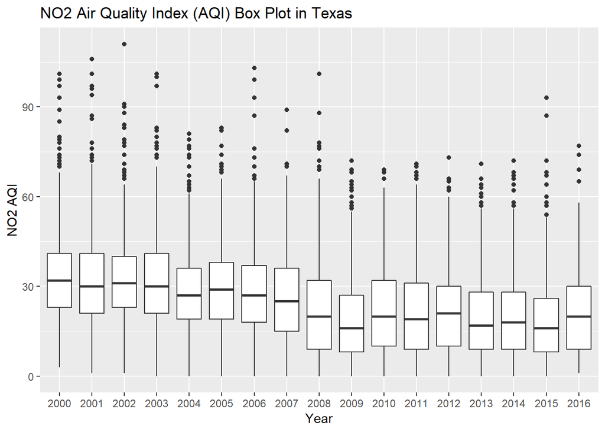

```r
tidy_df %>%
  filter(State == "Texas") %>%
  ggplot(aes(x=year, y=`NO2 AQI`)) +
  geom_boxplot() +
  labs(title = "NO2 Air Quality Index (AQI) Box Plot in Texas", x = "Year", y = "NO2 AQI")
```

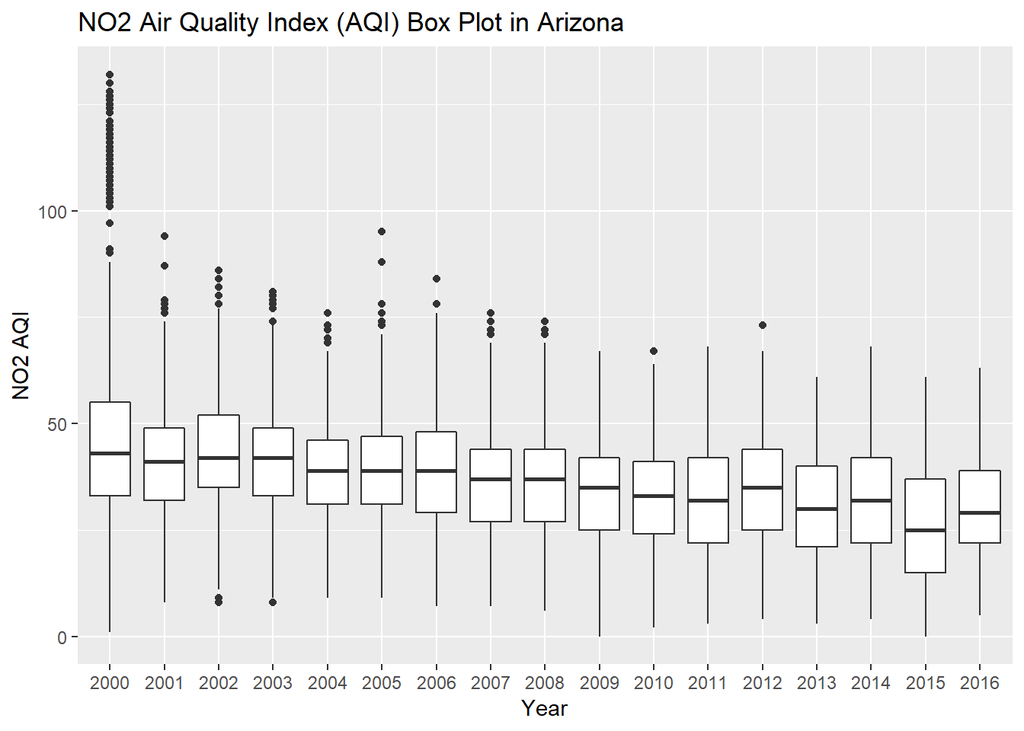

```r
tidy_df %>%
  filter(State == "Arizona") %>%
  ggplot(aes(x=year, y=`NO2 AQI`)) +
  geom_boxplot() +
  labs(title = "NO2 Air Quality Index (AQI) Box Plot in Arizona", x = "Year", y = "NO2 AQI")
```

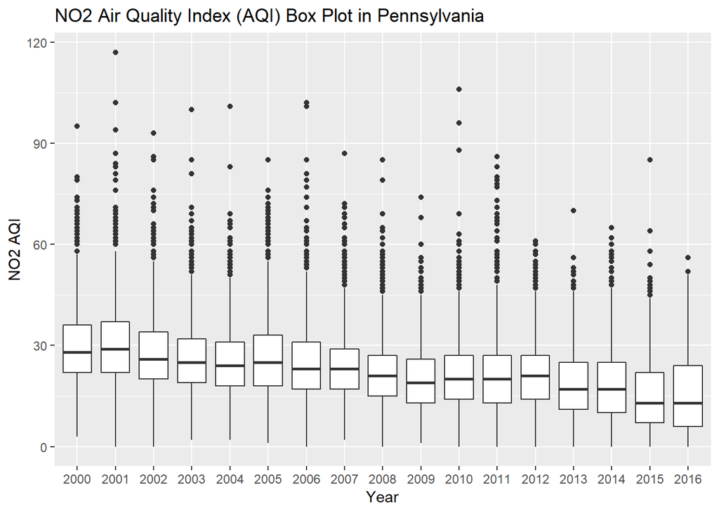

```r
tidy_df %>%
  filter(State == "Pennsylvania") %>%
  ggplot(aes(x=year, y=`NO2 AQI`)) +
  geom_boxplot() +
  labs(title = "NO2 Air Quality Index (AQI) Box Plot in Pennsylvania", x = "Year", y = "NO2 AQI")
```

# 3. Machine Learning

Now we will create a model, test a hypothesis on the model, and see the accuracy of the model. As mentioned before, the data in 2016 was only for the first few months so we will not be using the 2016 data in creating our model. Also, since all states didn’t consistently have data throughout each year. So we will be using the data from the 14 states who had data between 2000 - 2015 to create and test our model. Now lets start to create our model and test it. For our model we will be using random forests.  
First, we must create our outcome data frame, so we know what the outcome should be. We will be predicting if there was an increase or decrease in NO2 AQI. Here, we get the difference between NO2 AQI in 2015 from the data in 2014.

```r
# 14 States with complete data between 2000 - 2015
train_states <- c("Arizona", "California", "Colorado", "District Of Columbia", "Florida", "Illinois", "Indiana", "Kansas", "Louisiana", "New York", "North Carolina", "Oklahoma", "Pennsylvania", "Texas")

temp_df1 <- tidy_df %>%
  filter((State %in% train_states) & year == 2015) %>%
  select(State, `NO2 AQI`) %>%
  group_by(State) %>%
  summarise(x = mean(`NO2 AQI`, na.rm = TRUE))

temp_df2 <- tidy_df %>%
  filter((State %in% train_states) & year == 2014) %>%
  select(State, `NO2 AQI`) %>%
  group_by(State) %>%
  summarise(x = mean(`NO2 AQI`, na.rm = TRUE))

outcome_df <- inner_join(temp_df1, temp_df2, by = "State")
colnames(outcome_df)[2] <- "year2015"
colnames(outcome_df)[3] <- "year2014"
outcome_df <- outcome_df %>%
  mutate(diff = year2015 - year2014) %>%
  mutate(direction = ifelse(diff > 0, "up", "down")) %>%
  select(State, direction)
```

Now lets create our predictor data frame, so that we can build a classifier for the outcome. We will use as much data as we can, so we will use all the data between 2000 and 2014.

```r
predictor_df <- tidy_df %>%
  filter((State %in% train_states) & year <= 2014) %>%
  select(State, year, `NO2 AQI`) %>%
  group_by(State, year) %>%
  summarise(x = mean(`NO2 AQI`, na.rm = TRUE))
colnames(predictor_df)[3] <- "NO2AQI"

wide_df <- predictor_df %>%
  ungroup() %>%
  select(State, year, NO2AQI) %>%
  tidyr::spread(year, NO2AQI)

final_df <- wide_df %>%
  inner_join(select(outcome_df, State, direction), by="State") %>%
  mutate(direction=factor(direction, levels=c("down", "up")))
```

Now that we have constructed the necessary data frames to train our model, lets find its error rate (%). We will create a small model using a random forest, and half of our data to train, and the other half to test. This is a simple way to train and test our data, but should be fine to see its error rate.  
Error Rate = (pred_down_obs_up + pred_up_obs_down) / (sum of all values in table)  
Thus, Error Rate = 16.667%

```r
set.seed(123456789)
test_rf_df <- final_df %>%
  group_by(direction) %>%
  sample_frac(.5) %>%
  ungroup()

train_rf_df <- final_df %>%
  anti_join(test_rf_df, by="State")

rf_fit <- train(direction~.,
                data = train_rf_df %>% select(-State),
                method="rf",
                trControl=trainControl(method="none"))
rf_fit
```

```
## Random Forest
##
##  8 samples
## 15 predictors
##  2 classes: 'down', 'up'
##
## No pre-processing
## Resampling: None
```

```r
test_predictions <- predict(rf_fit, newdata = test_rf_df %>% select(-State))

table(pred=test_predictions,
      observed=test_rf_df$direction)
```

```
##       observed
## pred   down up
##   down    4  1
##   up      0  1
```

Now that we have seen that we have a fairly low error rate we can create our model, and test a hypothesis. For our hypothesis, we will test how accurate our model is when we use a small random forest to train it vs. using a big random forest to train it. In order to test the effectiveness of the model we create we will use 5-fold cross validation.  
To create our model, we will first partition the data. Then we will fit 2 models. One model will use one tree, which just a decision tree, and the other will use 1000 trees. After creating our models we can see that our small model had its highest ROC value at 0.95, which is good, but our big model had a ROC value of 1, which is the best. If you don’t understand what I mean by ROC value, here are 3 good resources to learn about them: [Source 1](https://www.medcalc.org/manual/roc-curves.php), [Source 2](http://gim.unmc.edu/dxtests/roc3.htm), and [Source 3](https://acutecaretesting.org/en/articles/roc-curves-what-are-they-and-how-are-they-used).

```r
set.seed(123456789)

cv_partition <- createFolds(final_df$direction, k=5)

fit_control <- trainControl(
  method = "cv",
  number = 5,
  indexOut = cv_partition,
  summaryFunction=twoClassSummary,
  classProbs=TRUE,
  savePredictions=TRUE)

small_rf_fit <- train(direction~.,
                    data=final_df,
                    method = "rf",
                    ntree = 1,
                    trControl = fit_control,
                    metric="ROC")
big_rf_fit <- train(direction~.,
                    data=final_df,
                    method = "rf",
                    ntree = 1000,
                    trControl = fit_control,
                    metric="ROC")
show(small_rf_fit)
```

```
## Random Forest
##
## 14 samples
## 16 predictors
##  2 classes: 'down', 'up'
##
## No pre-processing
## Resampling: Cross-Validated (5 fold)
## Summary of sample sizes: 11, 11, 11, 11, 12
## Resampling results across tuning parameters:
##
##   mtry  ROC   Sens  Spec
##    2    0.65  0.7   0.6
##   15    0.95  0.9   1.0
##   28    0.60  0.8   0.4
##
## ROC was used to select the optimal model using the largest value.
## The final value used for the model was mtry = 15.
```

```r
show(big_rf_fit)
```

```
## Random Forest
##
## 14 samples
## 16 predictors
##  2 classes: 'down', 'up'
##
## No pre-processing
## Resampling: Cross-Validated (5 fold)
## Summary of sample sizes: 11, 11, 11, 11, 12
## Resampling results across tuning parameters:
##
##   mtry  ROC  Sens  Spec
##    2    1    0.9   1
##   15    1    0.9   1
##   28    1    0.9   1
##
## ROC was used to select the optimal model using the largest value.
## The final value used for the model was mtry = 2.
```

Now that we have created both of our models, we can compare them. In our comparison plot we can see the big model has no spread, which makes sense since it has ROC = 1. And, our decision tree model had some spread since its sensitivity was 0.9, which means 90% of the time it would get the correct answer. From our hypothesis test we can see that there was a small inrease, which is statistically insignificant. Also, since our p-value is kind of big, 0.3465935, we can say that there was not enough evidence to reject the null hypothesis. [Here](http://www.hcbravo.org/IntroDataSci/bookdown-notes/experiment-design-and-hypothesis-testing.html) is a resource to understand hypothesis testing.

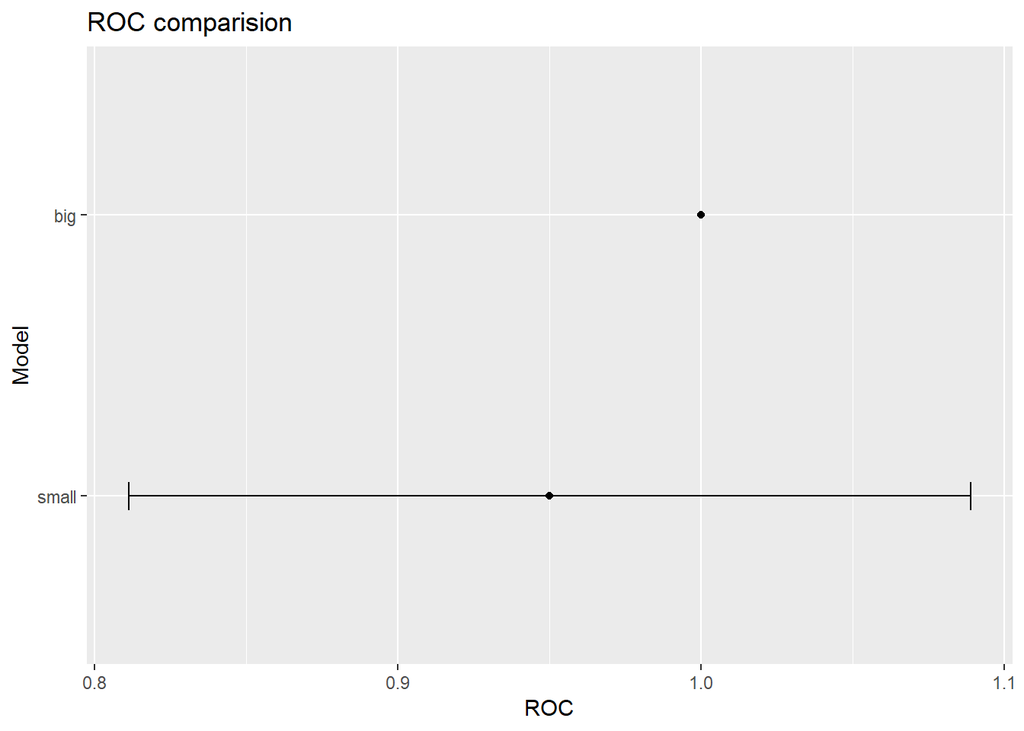

```r
model_comparison <- resamples(list(small = small_rf_fit, big=big_rf_fit))
ggplot(model_comparison) +
  labs(title="ROC comparision", x="Model", y="ROC")
```

```r
comparison_df <- model_comparison %>%
  as_tibble() %>%
  gather("model", "roc", -Resample) %>%
  mutate(model=factor(model, levels=c("small","big")))

comparison_df %>%
  lm(roc~model,data=.) %>%
  tidy() %>%
  knitr::kable()
```

| term | estimate | std.error | statistic | p.value |
| --- | --- | --- | --- | --- |
| (Intercept) | 0.95 | 0.0353553 | 26.87006 | 0.0000000 |
| modelbig | 0.05 | 0.0500000 | 1.00000 | 0.3465935 |

Now, lets create our ROC curves. We will filter each model to the mtry, where the model worked the best, 2 for the big model, and 15 for the small model. Then we will plot the ROC curves. Since the we know the the big model had a ROC = 1, it makes sense for the curve to be like that. This is because ROC is really the AUROC, area under the ROC. For the small model you can see that it takes some time before having 100% true positive rate, which makes sense from what we saw earlier.

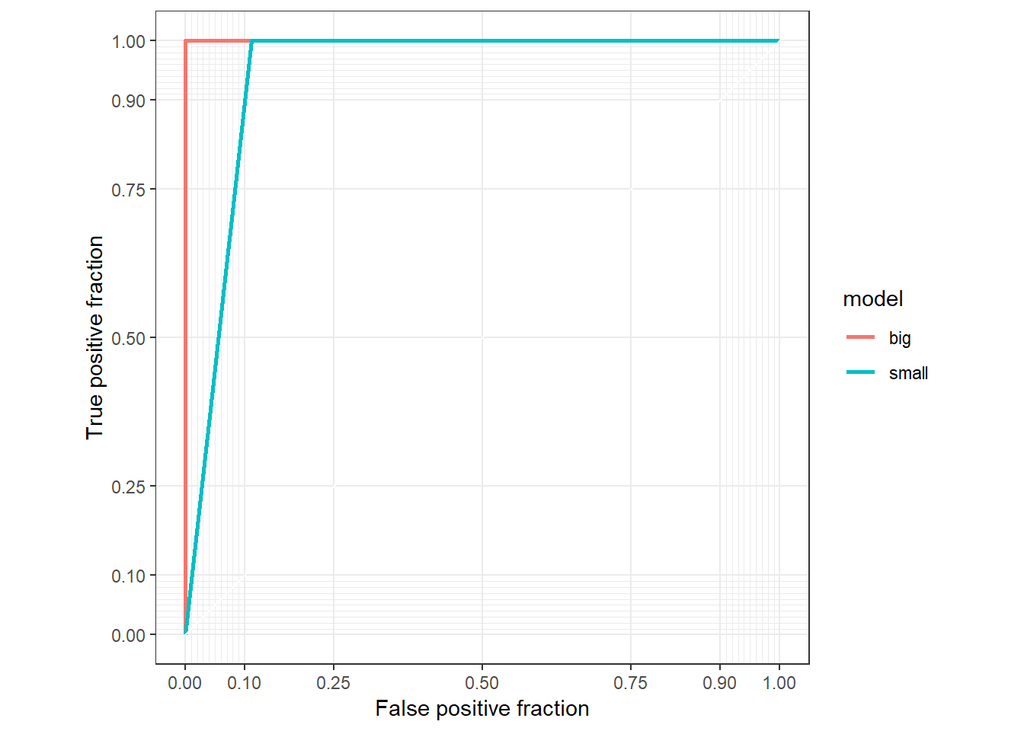

```r
roc_df <-
  big_rf_fit$pred %>%
    filter(mtry == 2) %>%
    mutate(model = "big") %>%
    bind_rows(small_rf_fit$pred %>%
                filter(mtry == 15) %>%
                mutate(model = "small"))
roc_df %>%
  ggplot(aes(m=up,
             d=factor(obs, levels=c("down","up")),
             color=model)) +
    geom_roc(n.cuts=0) +
    coord_equal() +
    style_roc()
```